# Project Foundations for Data Science: FoodHub Data Analysis

**Marks: 60**

### Context

The number of restaurants in New York is increasing day by day. Lots of students and busy professionals rely on those restaurants due to their hectic lifestyles. Online food delivery service is a great option for them. It provides them with good food from their favorite restaurants. A food aggregator company FoodHub offers access to multiple restaurants through a single smartphone app.

The app allows the restaurants to receive a direct online order from a customer. The app assigns a delivery person from the company to pick up the order after it is confirmed by the restaurant. The delivery person then uses the map to reach the restaurant and waits for the food package. Once the food package is handed over to the delivery person, he/she confirms the pick-up in the app and travels to the customer's location to deliver the food. The delivery person confirms the drop-off in the app after delivering the food package to the customer. The customer can rate the order in the app. The food aggregator earns money by collecting a fixed margin of the delivery order from the restaurants.

### Objective

The food aggregator company has stored the data of the different orders made by the registered customers in their online portal. They want to analyze the data to get a fair idea about the demand of different restaurants which will help them in enhancing their customer experience. Suppose you are hired as a Data Scientist in this company and the Data Science team has shared some of the key questions that need to be answered. Perform the data analysis to find answers to these questions that will help the company to improve the business.

### Data Description

The data contains the different data related to a food order. The detailed data dictionary is given below.

### Data Dictionary

- order_id: Unique ID of the order
- customer_id: ID of the customer who ordered the food
- restaurant_name: Name of the restaurant
- cuisine_type: Cuisine ordered by the customer
- cost: Cost of the order
- day_of_the_week: Indicates whether the order is placed on a weekday or weekend (The weekday is from Monday to Friday and the weekend is Saturday and Sunday)
- rating: Rating given by the customer out of 5
- food_preparation_time: Time (in minutes) taken by the restaurant to prepare the food. This is calculated by taking the difference between the timestamps of the restaurant's order confirmation and the delivery person's pick-up confirmation.
- delivery_time: Time (in minutes) taken by the delivery person to deliver the food package. This is calculated by taking the difference between the timestamps of the delivery person's pick-up confirmation and drop-off information

### Let us start by importing the required libraries

```python
# import libraries for data manipulation
import numpy as np
import pandas as pd

# import libraries for data visualization
import matplotlib.pyplot as plt
import seaborn as sns
import matplotlib
```

```python
from google.colab import drive
drive.mount('/content/drive')
```

### Understanding the structure of the data

```python
# read the data
df = pd.read_csv('/content/drive/MyDrive/Colab Notebooks/Course 1/Course1_Project/foodhub_order.csv')
# returns the first 5 rows
df.head()
```

|  | order_id | customer_id | restaurant_name | cuisine_type | cost_of_the_order | day_of_the_week | rating | food_preparation_time | delivery_time |
| --- | --- | --- | --- | --- | --- | --- | --- | --- | --- |
| 0 | 1477147 | 337525 | Hangawi | Korean | 30.75 | Weekend | Not given | 25 | 20 |
| 1 | 1477685 | 358141 | Blue Ribbon Sushi Izakaya | Japanese | 12.08 | Weekend | Not given | 25 | 23 |
| 2 | 1477070 | 66393 | Cafe Habana | Mexican | 12.23 | Weekday | 5 | 23 | 28 |
| 3 | 1477334 | 106968 | Blue Ribbon Fried Chicken | American | 29.20 | Weekend | 3 | 25 | 15 |
| 4 | 1478249 | 76942 | Dirty Bird to Go | American | 11.59 | Weekday | 4 | 25 | 24 |

#### Observations:

The DataFrame has 9 columns as mentioned in the Data Dictionary. Data in each row corresponds to the order placed by a customer.

### **Question 1:** How many rows and columns are present in the data? [0.5 mark]

```python
# Using the shape function to determine the dimensions of the dataframe.
print(df.shape)
```

```
(1898, 9)
```

#### Observations:

The Dataframe has 1898 rows and 9 columns are present in the data.

### **Question 2:** What are the datatypes of the different columns in the dataset? (The info() function can be used) [0.5 mark]

```python
# Use info() to print a concise summary of the DataFrame
print(df.info())
```

```
<class 'pandas.core.frame.DataFrame'>
RangeIndex: 1898 entries, 0 to 1897
Data columns (total 9 columns):
 #   Column                 Non-Null Count  Dtype
---  ------                 --------------  -----
 0   order_id               1898 non-null   int64
 1   customer_id            1898 non-null   int64
 2   restaurant_name        1898 non-null   object
 3   cuisine_type           1898 non-null   object
 4   cost_of_the_order      1898 non-null   float64
 5   day_of_the_week        1898 non-null   object
 6   rating                 1898 non-null   object
 7   food_preparation_time  1898 non-null   int64
 8   delivery_time          1898 non-null   int64
dtypes: float64(1), int64(4), object(4)
memory usage: 133.6+ KB
None
```

#### Observations:

The columns order_id, customer_id, food_preparation_time, and delivery_time have the interger datatype.

The column cost_of_the_order has a float datatype.

The columns restaurant_name, cuisine_type, day_of_the_week, and rating have a datatype of object.

Another observation is that all columns have non-null.

### **Question 3:** Are there any missing values in the data? If yes, treat them using an appropriate method. [1 mark]

```python
# This code sums the missing values in each column
df.isna().sum()
```

```
order_id                 0
customer_id              0
restaurant_name          0
cuisine_type             0
cost_of_the_order        0
day_of_the_week          0
rating                   0
food_preparation_time    0
delivery_time            0
dtype: int64
```

#### Observations:

The isna() function didn't detect any missing values in this dataframe.

### **Question 4:** Check the statistical summary of the data. What is the minimum, average, and maximum time it takes for food to be prepared once an order is placed? [2 marks]

```python
# Using describe() to get the statistical summary of the dataframe. ".T" is to transpose it so it's more readable.
df.describe().T
```

|  | count | mean | std | min | 25% | 50% | 75% | max |
| --- | --- | --- | --- | --- | --- | --- | --- | --- |
| order_id | 1898.0 | 1.477496e+06 | 548.049724 | 1476547.00 | 1477021.25 | 1477495.50 | 1.477970e+06 | 1478444.00 |
| customer_id | 1898.0 | 1.711685e+05 | 113698.139743 | 1311.00 | 77787.75 | 128600.00 | 2.705250e+05 | 405334.00 |
| cost_of_the_order | 1898.0 | 1.649885e+01 | 7.483812 | 4.47 | 12.08 | 14.14 | 2.229750e+01 | 35.41 |
| food_preparation_time | 1898.0 | 2.737197e+01 | 4.632481 | 20.00 | 23.00 | 27.00 | 3.100000e+01 | 35.00 |
| delivery_time | 1898.0 | 2.416175e+01 | 4.972637 | 15.00 | 20.00 | 25.00 | 2.800000e+01 | 33.00 |

#### Observations:

The average time of food preparation is 27.37 minutes. The fastest time for the preparation of the food is 20 minutes. And the slowest time to prepare the food is 35 minutes. The standard deviation is 4.6 min which means that the time of food preparation doesn't vary as much.

Another observation is that most of the orders are below the $22 dollars, this means that the customers usually order low-cost foods.

The delivery time doesn't vary as much because the standar deviation is of 4.9 minutes.

### **Question 5:** How many orders are not rated? [1 mark]

```python
# In this code a new dataframe was created using just the rating column. Also the value_counts() was used to count each element of the rating column.
df2 = df.rating.value_counts()
print(df2,"\n") #prints the counts of each element of the rating series.

print(df2['Not given'],"orders were not rated","\n") #prints only the counts of orders that are not rated.

print(df2['Not given']/1898*100,"% were not rated")
```

```
Not given    736
5            588
4            386
3            188
Name: rating, dtype: int64

736 orders were not rated

38.77766069546891 % were not rated
```

#### Observations:

The above information states that 736 orders were not rated out of 1898 orders. This means that 38.7% was not rated, which is a significant percentage.

### Exploratory Data Analysis (EDA)

### **Question 6:** Explore all the variables and provide observations on their distributions. (Generally, histograms, boxplots, countplots, etc. are used for univariate exploration.) [9 marks]

**order ID**

```python
# Gives the amount of unique orders
df['order_id'].nunique()
```

```
1898
```

Observations:

There are 1898 unique orders in the data.

**customer ID**

```python
# Gives the amount of unique customers
df['customer_id'].nunique()
```

```
1200
```

```
['customer_id']
```

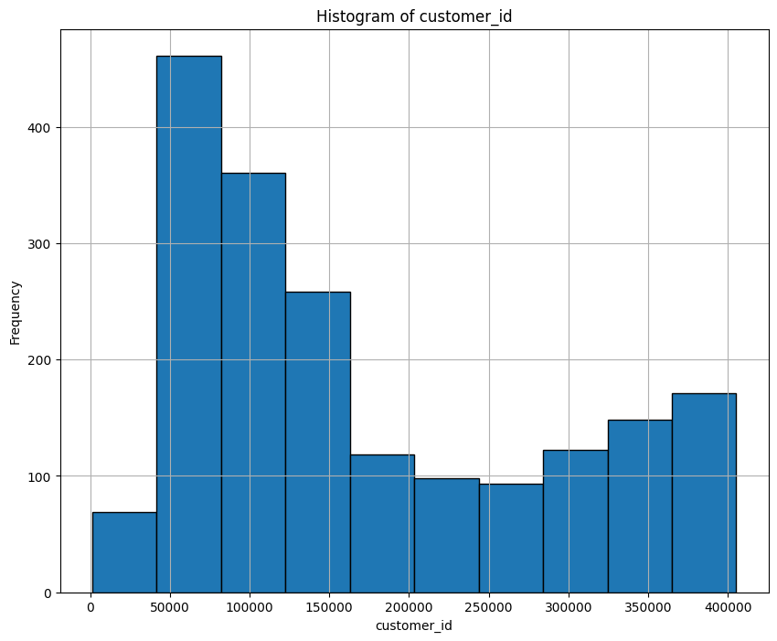

```python
# This code generates histograms for univariate variables that are continuous
variable_list_cont = ['customer_id']
print(variable_list_cont)

## This definition plots histograms
def plot_histograms(dataframe):
    for column in variable_list_cont: #This for loop runs for each column that is in the variable list.
        plt.figure(figsize=(10, 8)) # customize the size of each plot
        plt.hist(dataframe[column], edgecolor='k') #plot histogram
        # Customize the title, and labels of the axis.
        plt.title(f'Histogram of {column}')
        plt.xlabel(column)
        plt.ylabel('Frequency')
        plt.grid(True)
        plt.show()

# Call the function to plot histograms
plot_histograms(df)
```

Observations:

There are 1200 customers in this database. If the customer ID is given in the order of joining the app, this histogram can be useful.

**restaurant name**

```
['restaurant_name']
```

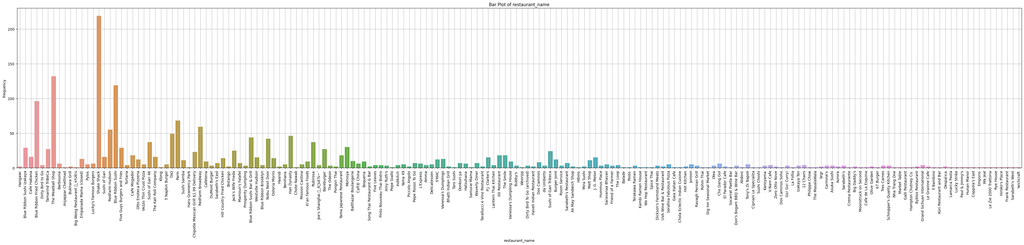

```python
# This code generates a bar plot for restaurant name, since its a categorical variable.
variable_list_cat = ['restaurant_name']
print(variable_list_cat)

## This definition plots bar plots
def plot_barplots(dataframe):
    for column in variable_list_cat: #This for loop runs for each column that is in the variable list.
        plt.figure(figsize=(50, 8)) # customize the size of each plot

        sns.countplot(data=df, x=column); #plot bar plot
        # Customize the title, and labels of the axis.
        plt.title(f'Bar Plot of {column}')
        plt.xticks (rotation=90) # rotate the xticks names so it can be more readable.
        plt.xlabel(column)
        plt.ylabel('Frequency')
        plt.grid(True)
        plt.show()

# Call the function to plot
plot_barplots(df)
```

Observations: The amount of restaurants is large. But only a few get the most orders. For example, Shake Shack is significantly the most popular restaurant in the platform.

**cuisine type**

```
['cuisine_type']
```

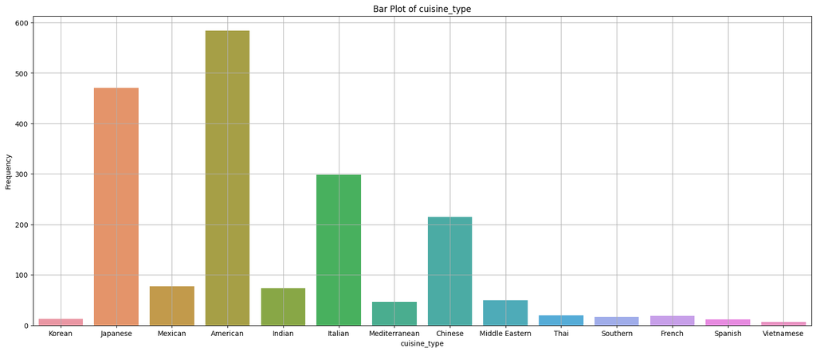

```python
# This code generates bar plots for univariate variables that are categorical
variable_list_cat = ['cuisine_type']
print(variable_list_cat)

## This definition plots bar plots
def plot_barplots(dataframe):
    for column in variable_list_cat: #This for loop runs for each column that is in the variable list.
        plt.figure(figsize=(20, 8)) # customize the size of each plot

        sns.countplot(data=df, x=column); #plot bar plot
        # Customize the title, and labels of the axis.
        plt.title(f'Bar Plot of {column}')
        plt.xlabel(column)
        plt.ylabel('Frequency')
        plt.grid(True)
        plt.show()

# Call the function to plot Bar plots
plot_barplots(df)
```

Observations: The most popular cuisines among customers are: American, Japanese, Italian and Chinese.

**cost_of_the_order**

```
['cost_of_the_order']
```

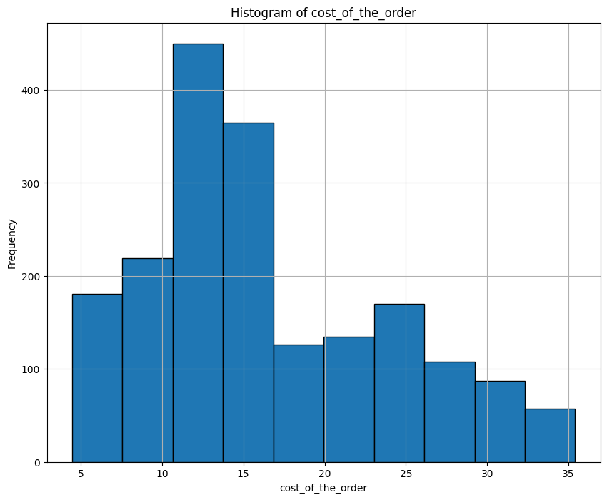

```python
# This code generates histograms for univariate variables that are continuous
variable_list_cont = ['cost_of_the_order']
print(variable_list_cont)

## This definition plots histograms
def plot_histograms(dataframe):
    for column in variable_list_cont: #This for loop runs for each column that is in the variable list.
        plt.figure(figsize=(10, 8)) # customize the size of each plot
        plt.hist(dataframe[column], edgecolor='k') #plot histogram
        # Customize the title, and labels of the axis.
        plt.title(f'Histogram of {column}')
        plt.xlabel(column)
        plt.ylabel('Frequency')
        plt.grid(True)
        plt.show()

# Call the function to plot histograms
plot_histograms(df)
```

```
['cost_of_the_order']
```

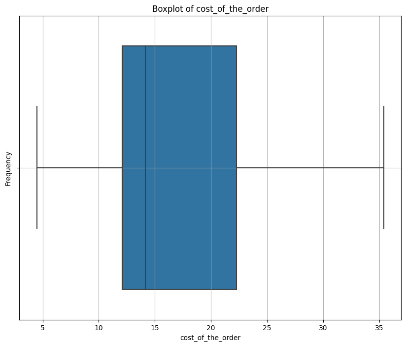

```python
# This code is meant for creating boxplots for different variables.
variable_numbers_list = ['cost_of_the_order'] #The order id was skipped because is a unique value
print(variable_numbers_list)

## Plot Boxplots
def plot_boxplot (dataframe):
  for variable in variable_numbers_list: #This for loop runs for each column that is in the variable list.
        plt.figure(figsize=(10, 8))
        sns.boxplot(data=dataframe, x=variable); #plot boxplot
        # Customize title and axis labels
        plt.title(f'Boxplot of {variable}')
        plt.xlabel(variable)
        plt.ylabel('Frequency')
        plt.grid(True)
        plt.show()
# Call the function to plot boxplots
plot_boxplot(df)
```

Observations:

The histogram and boxplot show that the distributon is right skewed. The mean on the boxplot is shown that is clearly on the low cost side.

**day of the week**

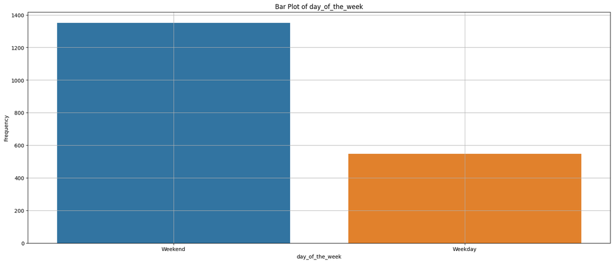

```python
# This code generates bar plots for univariate variables that are categorical
variable_list_cat = ['day_of_the_week']

## This definition plots bar plots
def plot_barplots(dataframe):
    for column in variable_list_cat: #This for loop runs for each column that is in the variable list.
        plt.figure(figsize=(20, 8)) # customize the size of each plot

        sns.countplot(data=df, x=column); #plot bar plot
        # Customize the title, and labels of the axis.
        plt.title(f'Bar Plot of {column}')
        plt.xlabel(column)
        plt.ylabel('Frequency')
        plt.grid(True)
        plt.show()

# Call the function to plot Bar plots
plot_barplots(df)
```

Observations: The customers order on the app more frequently during the weekends.

**rating**

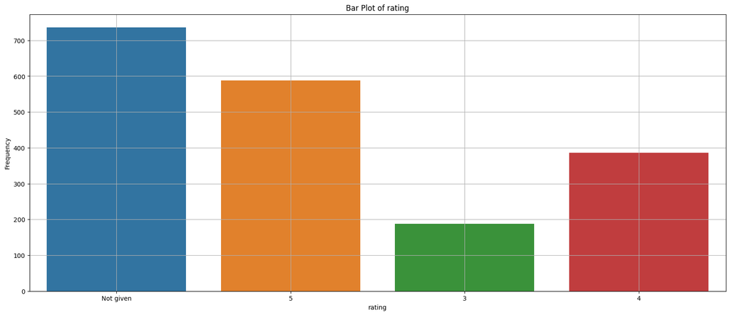

```python
# This code generates bar plots for univariate variables that are categorical
variable_list_cat = ['rating']

## This definition plots bar plots
def plot_barplots(dataframe):
    for column in variable_list_cat: #This for loop runs for each column that is in the variable list.
        plt.figure(figsize=(20, 8)) # customize the size of each plot

        sns.countplot(data=df, x=column); #plot bar plot
        # Customize the title, and labels of the axis.
        plt.title(f'Bar Plot of {column}')
        plt.xlabel(column)
        plt.ylabel('Frequency')
        plt.grid(True)
        plt.show()

# Call the function to plot Bar plots
plot_barplots(df)
```

Observations:

**food preparation time**

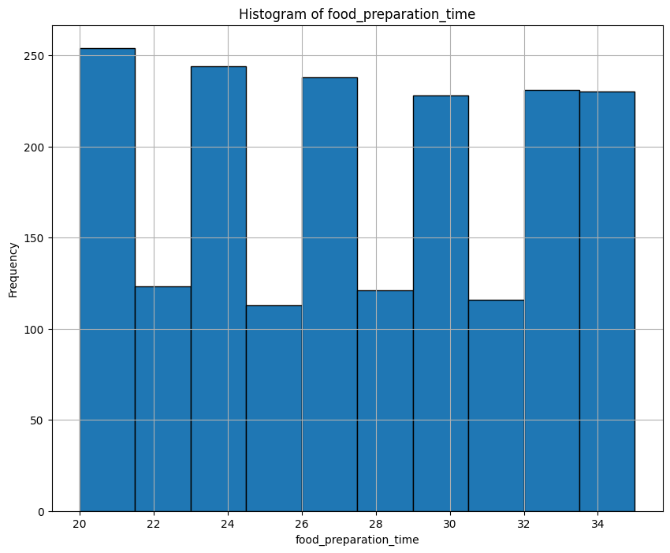

```
['food_preparation_time']
```

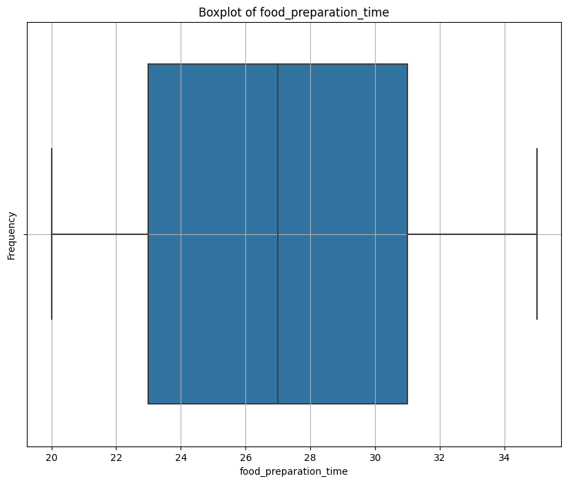

```python
# This code generates histograms for univariate variables that are continuous
variable_list_cont = ['food_preparation_time']

## This definition plots histograms
def plot_histograms(dataframe):
    for column in variable_list_cont: #This for loop runs for each column that is in the variable list.
        plt.figure(figsize=(10, 8)) # customize the size of each plot
        plt.hist(dataframe[column], edgecolor='k') #plot histogram
        # Customize the title, and labels of the axis.
        plt.title(f'Histogram of {column}')
        plt.xlabel(column)
        plt.ylabel('Frequency')
        plt.grid(True)
        plt.show()

# Call the function to plot histograms
plot_histograms(df)

# Get the variable list for continuous variables.
variable_numbers_list = ['food_preparation_time']
print(variable_numbers_list)

## Plot Boxplots
def plot_boxplot (dataframe):
  for variable in variable_numbers_list: #This for loop runs for each column that is in the variable list.
        plt.figure(figsize=(10, 8))
        sns.boxplot(data=dataframe, x=variable); #plot boxplot
        # Customize title and axis labels
        plt.title(f'Boxplot of {variable}')
        plt.xlabel(variable)
        plt.ylabel('Frequency')
        plt.grid(True)
        plt.show()
# Call the function to plot boxplots
plot_boxplot(df)
```

Observations:

The food preparation time, doesn't have a normal distribution. It seems that it doesn't vary as much and the mean is centralized.

**delivery time**

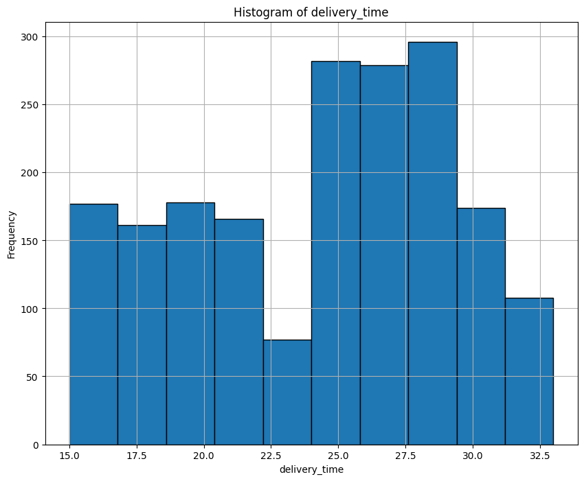

```
['delivery_time']
```

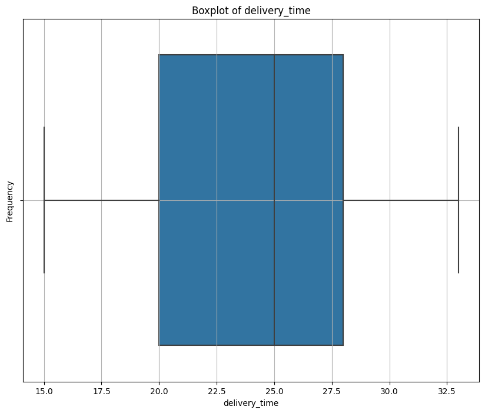

```python
# This code generates histograms for univariate variables that are continuous
variable_list_cont = ['delivery_time']

## This definition plots histograms
def plot_histograms(dataframe):
    for column in variable_list_cont: #This for loop runs for each column that is in the variable list.
        plt.figure(figsize=(10, 8)) # customize the size of each plot
        plt.hist(dataframe[column], edgecolor='k') #plot histogram
        # Customize the title, and labels of the axis.
        plt.title(f'Histogram of {column}')
        plt.xlabel(column)
        plt.ylabel('Frequency')
        plt.grid(True)
        plt.show()

# Call the function to plot histograms
plot_histograms(df)

# Get the variable list for continuous variables.
variable_numbers_list = ['delivery_time']
print(variable_numbers_list)

## Plot Boxplots
def plot_boxplot (dataframe):
  for variable in variable_numbers_list: #This for loop runs for each column that is in the variable list.
        plt.figure(figsize=(10, 8))
        sns.boxplot(data=dataframe, x=variable); #plot boxplot
        # Customize title and axis labels
        plt.title(f'Boxplot of {variable}')
        plt.xlabel(variable)
        plt.ylabel('Frequency')
        plt.grid(True)
        plt.show()
# Call the function to plot boxplots
plot_boxplot(df)
```

Observations: The mean seems to have longer times, and it's not as centralized as the food preparation time. This is very evident in the boxplot as well as the histogram.

### **Question 7**: Which are the top 5 restaurants in terms of the number of orders received? [1 mark]

```python
# using the value_counts() on the restaurant_name column, print it and it will give the first 5 elements with more frequencies.
df_restaurant = df.restaurant_name.value_counts()
df_restaurant
```

```
Shake Shack                  219
The Meatball Shop            132
Blue Ribbon Sushi            119
Blue Ribbon Fried Chicken     96
Parm                          68
                            ...
Sushi Choshi                   1
Dos Caminos Soho               1
La Follia                      1
Philippe Chow                  1
'wichcraft                     1
Name: restaurant_name, Length: 178, dtype: int64
```

#### Observations:

The top 5 restaurants that receive more orders are Shake Shack, The Meatball Shop, Blue Ribbon Sushi, Blue Ribbon Fried Chicken, and Parm

### **Question 8**: Which is the most popular cuisine on weekends? [1 mark]

```
day_of_the_week  Weekday  Weekend
cuisine_type
American             169      415
Chinese               52      163
French                 5       13
Indian                24       49
Italian               91      207
Japanese             135      335
Korean                 2       11
Mediterranean         14       32
Mexican               24       53
Middle Eastern        17       32
Southern               6       11
Spanish                1       11
Thai                   4       15
Vietnamese             3        4
```

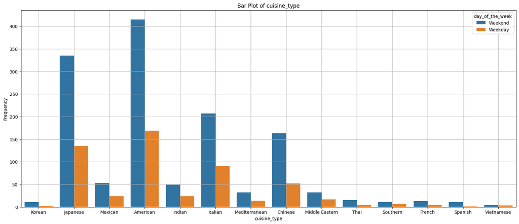

```python
# Making a crosstable to find the frequencies of each combination.
frequency_cuisine_df = pd.crosstab(index=df['cuisine_type'], columns=df['day_of_the_week'])
print(frequency_cuisine_df)

## Plot bar plot of the cuisine type by the day of the week (weekday or weekend)
# Just using the cuisine_type variable
variable_list_cat = ['cuisine_type' ]

## This definition plots bar plots
def plot_barplots(dataframe):
    for column in variable_list_cat: #This for loop runs for each column that is in the variable list.
        plt.figure(figsize=(20, 8)) # customize the size of each plot

        sns.countplot(data=df, x=column, hue='day_of_the_week'); #plot bar plot per day of the week
        # Customize the title, and labels of the axis.
        plt.title(f'Bar Plot of {column}')
        plt.xlabel(column)
        plt.ylabel('Frequency')
        plt.grid(True)
        plt.show()

# Call the function to plot Bar plots
plot_barplots(df)
```

#### Observations:

The cross table gives the specific value of the most popular cuisine during the weekends. But also the bar plot shows evidently that **the American cuisine is the most popular during the weekends.**

### **Question 9**: What percentage of the orders cost more than 20 dollars? [2 marks]

```python
# Creating a df filtered with the order cost above 20.
df_more_than_20 = df[df['cost_of_the_order'] > 20]
# df_more_than_20.shape # Checking shape
percentage = df_more_than_20.count()/df.count()*100
print('The percentage of orders that cost more than $20 dollars is',percentage['cost_of_the_order'],'%')
```

```
The percentage of orders that cost more than $20 dollars is 29.24130663856691 %
```

#### Observations:

The percentage of orders that cost more than $20 dollars is 29.24%

### **Question 10**: What is the mean order delivery time? [1 mark]

```python
# Using the mean function
df ['delivery_time'].mean ()
#df.describe().T #another way to look at this info.
```

```
24.161749209694417
```

#### Observations:

The mean is 24.16 minutes for the delivery time of orders.

### **Question 11:** The company has decided to give 20% discount vouchers to the top 3 most frequent customers. Find the IDs of these customers and the number of orders they placed. [1 mark]

```python
# using the value_counts() on the customer_id column, print it and it will give the all the customers ordered by higher frequent customer to the lowest.
df_customer = df.customer_id.value_counts()
df_customer[0:3] # prints only the first 3 most frequent customer.
```

```
52832    13
47440    10
83287     9
Name: customer_id, dtype: int64
```

#### Observations:

The top 3 most frequent customers' ids are: 52832, 47440, and 83287

### **Question 12**: Perform a multivariate analysis to explore relationships between the important variables in the dataset. (It is a good idea to explore relations between numerical variables as well as relations between numerical and categorical variables) [10 marks]

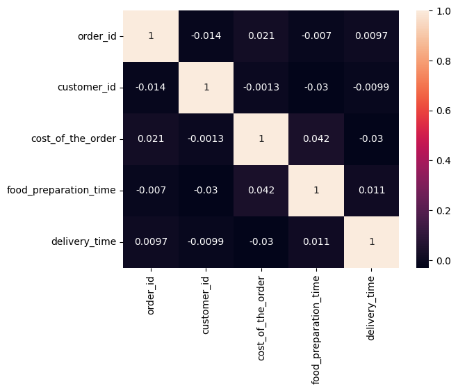

```python
# The code to plot a heat map between numerical variables
sns.heatmap(data=df[['order_id', 'customer_id',	'cost_of_the_order','food_preparation_time','delivery_time']].corr(), annot=True);
```

Observations:

The heatmap shows no correlation between the numerical variables.

**Relations between numerical and categorical variables**

**rating and food preparation time**

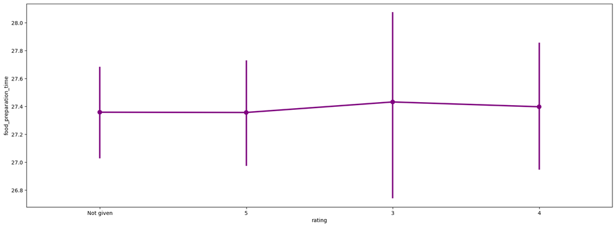

```python
# The following boxplots show the relation between the rating and the food preparation time. A pointplot was added for comparison.
plt.figure(figsize=(20,7))
#sns.boxplot(data=df, x='rating', y='food_preparation_time');
sns.pointplot(data=df, x = 'rating', y = 'food_preparation_time', color='purple');
```

Observations:

The food preparation time doesn't seem to correlate with the rating.

**rating and delivery time**

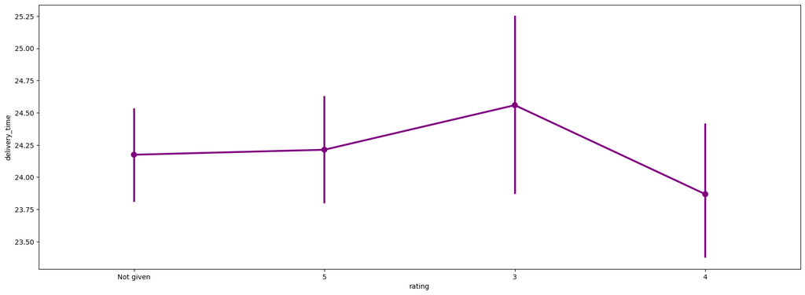

```python
# The following pointplot shows the relation between the rating and the delivery time.
plt.figure(figsize=(20,7))
#sns.boxplot(data=df, x='rating', y='delivery_time');
sns.pointplot(data=df, x = 'rating', y = 'delivery_time', color='purple');
```

Observations:

The delivery time seems to have no correlation with the rating. The differences between the y axis are so small, that's why there's no significant correlation.

**rating and cost per order**

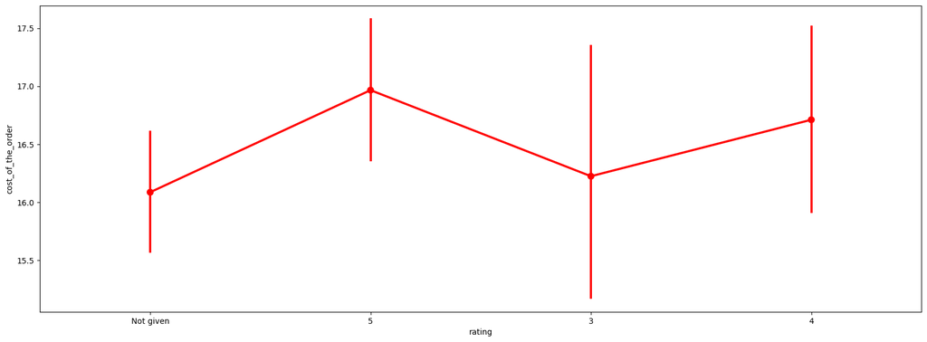

```python
# The following pointplot shows the relation between the rating and the cost of the order.
plt.figure(figsize=(20,7))
#sns.boxplot(data=df, x='rating', y='cost_of_the_order');
sns.pointplot(data=df, x = 'rating', y = 'cost_of_the_order', color='red');
```

Observations:

It seems that when the rating is higher, the cost of the order is also higher. The difference between the cost of the order across the ratings is small, the correlation is not that strong. Also the lowest cost of orders have not been given ratings.

**cuisine type and food preparation time**

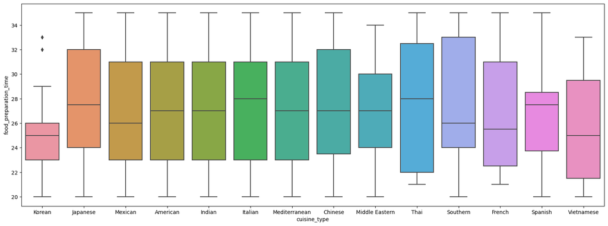

```python
# The following boxplots show the relation between the cuisine type and the food preparation time.
plt.figure(figsize=(20,7))
sns.boxplot(data=df, x='cuisine_type', y='food_preparation_time');
```

Observations:

The food preparation times is consistent across cousines.

The korean cousine is the one that takes the shortest time. But also has outliers.

**cuisine type and cost per order**

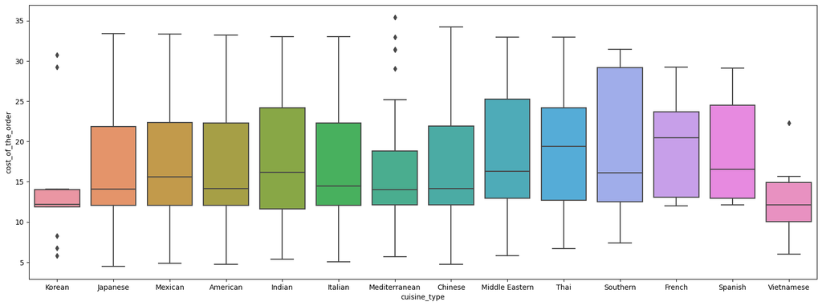

```python
# The following boxplots show the relation between the cuisine type and the cost of the order.
plt.figure(figsize=(20,7))
sns.boxplot(data=df, x='cuisine_type', y='cost_of_the_order');
```

Observations:

The majority of the cousines have the similar cost per order. Except for the Korean and Vietnamise cousine, which are significantly cheaper than the rest of them.

The Korean, Vietnamise and the Mediterranean have outliers on the cost per order. But the Korean is the only one that has outliers on the cheaper side.

**day of the week and time for delivery**

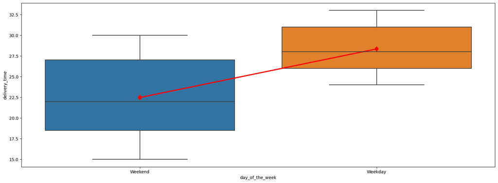

```python
# The following boxplots show the relation between the day of the week and the delivery time. A pointplot was added for comparison.
plt.figure(figsize=(20,7))
sns.boxplot(data=df, x='day_of_the_week', y='delivery_time');
sns.pointplot(data=df, x = 'day_of_the_week', y = 'delivery_time', color='red');
```

Observations:

The delivery time during the weekdays is significantly higher than on the weekends.

**day of the week and cost per order**

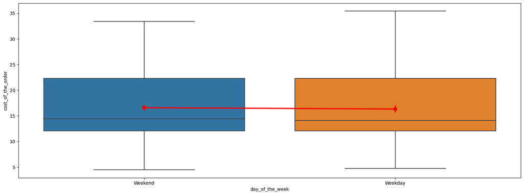

```python
# The following boxplots show the relation between the day of the week and the cost of the order. A pointplot was added for comparison.
plt.figure(figsize=(20,7))
sns.boxplot(data=df, x='day_of_the_week', y='cost_of_the_order');
sns.pointplot(data=df, x = 'day_of_the_week', y = 'cost_of_the_order', color='red');
```

Observations:

The cost of the order doesn't seem to correlate to the day of the week.

### **Question 13:** The company wants to provide a promotional offer in the advertisement of the restaurants. The condition to get the offer is that the restaurants must have a rating count of more than 50 and the average rating should be greater than 4. Find the restaurants fulfilling the criteria to get the promotional offer. [3 marks]

```python
# This code gets the restaurants with more than 50 rating counts and a rating mean greater than 4.

df_rating = df[df['rating'] != 'Not given'] # make a new df by filtering out the not given ratings.

df_rating['restaurant_name'].count() # Count the total ratings per restaurant. (Successfully taken out the Not given ratings)

vc = df_rating['restaurant_name'].value_counts () # vc is a variable that counts the frequency of ratings per restaurant.

df_requirement_1 = df_rating.loc[df_rating ['restaurant_name'].isin (vc [vc > 50].index)].copy() # Filters the first requirement, which is to have an amount of ratings above 50.

#The following lines converts the column rating values to float, so later the mean can be calculated.
df_requirement_1['rating'] = df_requirement_1['rating'].astype(float)
df_requirement_1['rating'].dtypes # check if it converted to float

#Create a pivot table to get the rating mean per restaurant.
rating_p_table = pd.pivot_table(df_requirement_1, index = ['restaurant_name'], values = ['rating'], aggfunc="mean")
print(rating_p_table)
```

```
                             rating
restaurant_name
Blue Ribbon Fried Chicken  4.328125
Blue Ribbon Sushi          4.219178
Shake Shack                4.278195
The Meatball Shop          4.511905
```

#### Observations:

The restaurants that can be granted the promotional offer are: Blue Ribbon Fried Chicken, Blue Ribbon Sushi, Shake Shack and the The Meatball Shop

### **Question 14:** The company charges the restaurant 25% on the orders having cost greater than 20 dollars and 15% on the orders having cost greater than 5 dollars. Find the net revenue generated by the company across all orders. [3 marks]

```python
# This code filters the dataframe and calculates the net revenue

# Disregard the orders that have a cost order less or equal to 5 dollars
df_cost_of_the_order = df[df['cost_of_the_order'] > 5] # make a new df by filtering out the prices that are 5 dollars or less.


# Makes a new column based on the condition given, and writes the value of the revenue by multiplyeing the company charges times the cost of the order.
df_cost_of_the_order.loc[df_cost_of_the_order['cost_of_the_order'] > 20, ['revenue']] = df_cost_of_the_order['cost_of_the_order']*0.25
df_cost_of_the_order.loc[df_cost_of_the_order['cost_of_the_order'] <= 20, ['revenue']] = df_cost_of_the_order['cost_of_the_order']*0.15

#Using the sum function on the revenue column will give us the net revenue.
total_revenue = df_cost_of_the_order['revenue'].sum()
#Print the result
print("The revenue generated across all orders was: $" , total_revenue , "dollars")
```

```
The revenue generated across all orders was: $ 6166.303 dollars
```

#### Observations:

The net revenue for all the orders so far is $6166.303 dollars

### **Question 15:** The company wants to analyze the total time required to deliver the food. What percentage of orders take more than 60 minutes to get delivered from the time the order is placed? (The food has to be prepared and then delivered.) [2 marks]

```python
# This code finds the percentage of the orders that take more than 60 min.
# Sum the times and place the value in a new column: "Total_Time"
df['Total_Time'] = df['food_preparation_time'] + df['delivery_time']

# The following code creates a new column "factor" that will later on help to calculate the percentage.
df.loc[df['Total_Time'] > 60, ['factor']] = df['Total_Time']/df['Total_Time'] # if the total time is higher than 60 it will give a value of 1 on the factor column
df.loc[df['Total_Time'] <= 60, ['factor']] = df['Total_Time']*0  # if the total time is lesser or equal to 60 it will give a value of 0 on the factor column

# Calculating the percentage
orders_above_60 = df['factor'].sum() # Summing up the factors will give the value of the orders that take longer than 60 min.
total_orders = df['factor'].count()  # Counting the total factor column, will give the total value of orders.
percentage_long_orders = orders_above_60 / total_orders * 100  # Calculate the percentage by doing a division and multiplying by 100.

# Print the result
print("The percentage of orders that take longer than 60 min is:", percentage_long_orders ,"%")
```

```
The percentage of orders that take longer than 60 min is: 10.537407797681771 %
```

#### Observations:

10.5% of orders take longer than 60 min. This is not a big significant percentage.

### **Question 16:** The company wants to analyze the delivery time of the orders on weekdays and weekends. How does the mean delivery time vary during weekdays and weekends? [2 marks]

```python
#Create a pivot table to get the delivery_time mean per day of the week.
Time_p_table = pd.pivot_table(df, index = ['day_of_the_week'], values = ['delivery_time'], aggfunc="mean")
print(Time_p_table)
```

```
                 delivery_time
day_of_the_week
Weekday              28.340037
Weekend              22.470022
```

#### Observations:

During the weekends the delivery time is lower than the delivery times on the weekdays. On the weekdays is 28.3 min and during the weekends is 22.47 min.

### Recommendations:

- My main recommendation is that the company should reach out to other restaurants that are within the most popular cuisines (American, Japanese, Italian and Chinese) and low cost. Since these are the main characteristics the clients are looking for.
- Another recommendation is that the business should analyze the reason why clients are not rating. The company can send reminders after a few minutes of the client receiving the order, to rate the service. Another strategy is to give a compensation to the client for rating, so that the client has a motive.
- Since during the weekdays the orders are less, the company can launch a campaign to motivate the clients to also order during weekdays. Also to keep the weekends to have a good service, more delivery workers should work during these days to keep the delivery times low.
- My last recommendation is to have more information on the customers, for example if the ID is given by the joining on the app. Knowing this information can give better insights for segmentation.